# IPL Ball-by-Ball: A Statistical Look

Team strength adjusted for opposition, venue effects, and what toss luck is actually worth

August 2026

This report asks three questions the summary dashboard can’t: which teams are *actually* good once you account for who they played, whether venues have a real effect on scoring once you separate that from the league’s year-on-year scoring inflation, and whether winning the toss is worth what everyone assumes it’s worth. 1095 matches and 260,920 deliveries, 2008–2024.

## Team strength, adjusted for opponent

A simple win percentage rewards teams for a soft schedule as much as for being good. The standard fix is a **Bradley–Terry model**: every match is a binomial trial where team *A*’s log-odds of beating team *B* is the difference in two latent “strength” scores, estimated jointly across all 1090 matches by logistic regression. A team’s rating only moves when it beats or loses to *strong* opposition — beating a weak team barely moves the needle.

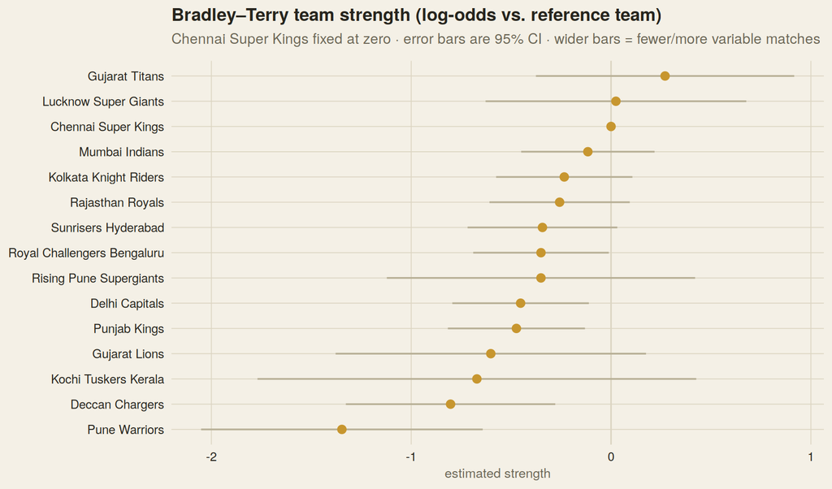

Gujarat Titans comes out on top once opponent quality is accounted for. Note how wide some of the intervals are — several mid-table teams are statistically indistinguishable from each other; the model simply hasn’t seen enough evidence to separate them.

## Is winning the toss actually worth anything?

Across 1090 matches, the toss-winning team also won the match 50.8% of the time — a chi-square test against a fair 50/50 split gives χ² = 0.3, p = 0.586. That’s not distinguishable from no edge at all.

But that number bundles two different decisions together. Teams that win the toss increasingly choose to field first (chasing under lights, dew, whatever the reasoning):

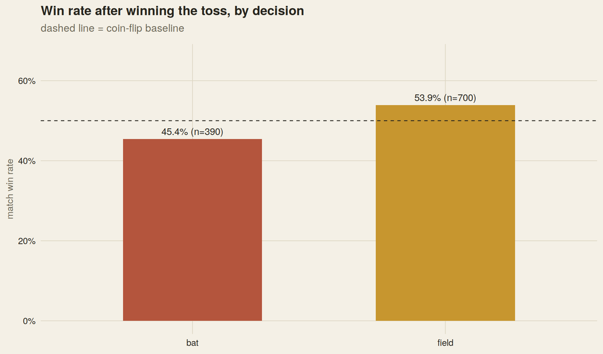

Electing to field first after winning the toss is worth meaningfully more than electing to bat — consistent with the chase-friendly, dew-affected, floodlit nature of most IPL matches.

## Does the venue actually matter, once you strip out league-wide scoring inflation?

Scoring has trended up across seasons (better pitches, shorter boundaries, batting depth). A raw “average score per venue” table conflates *when* a venue was used with *where* it is. A mixed-effects model separates the two: season is a fixed linear trend, venue is a random intercept.

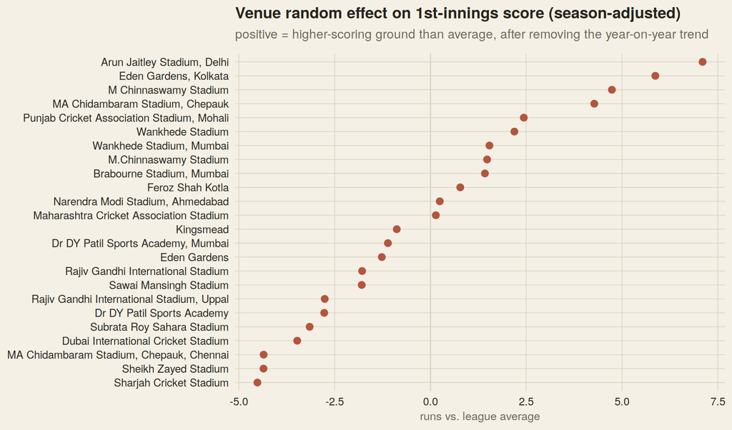

The spread here is smaller than raw per-venue averages would suggest — a chunk of what looks like a “high-scoring ground” in a naive table is really just that ground hosting more matches in recent, higher-scoring seasons.

## Death overs: how much more dangerous, really?

[figure not shown]

R 4.3.3 · lme4, ggplot2, dplyr · Bradley013Terry model fit via glm() on 1090 matches